# Final Project Report

Github link: https://github.com/Wenyu-ZHU/Final

```python
from IPython.display import HTML
HTML('''<script>
code_show=true;
function code_toggle() {
 if (code_show){
 $('div.input').hide();
 } else {
 $('div.input').show();
 }
 code_show = !code_show
}
$( document ).ready(code_toggle);
</script>
<form action="javascript:code_toggle()"><input type="submit" value="Click here to look at the raw code."></form>''')
```

# Abstract

This report is mainly to analyze the movies in the United States over the past 100 years. Through the study of movie genres, directors, and film elements, we know that people like to watch drama and action movies, some directors do have box office appeal and most of the film's budget and revenue are proportional.

# 1. Introduction and Background

## 1.1 Background

The movie market is booming nowadays, with billion-dollar box-office movies, many of which are American blockbusters. The Motion Picture Association of America (MPAA) released the 2018 Global Film Entertainment Market Data Report, with north American film market data as the core, showing a profound analysis of the volatile entertainment market. According to the report, global box-office receipts reached 41 billion dollars, including 11.9 billion dollars in North America with a 15 percent increase in film revenue. The number of screen games increased by 7% to nearly 190,000 worldwide. In North America, 1.3 billion moviegoers were seen in 2018, up 5% from 2017. Three-quarters of North Americans (263 million) have seen the film at least once in 2018. Among them, teenagers of 12-17 and 18-24 have the highest average attendance rate, 5.1 per year. with an increase in moviegoers in all except the age of 25-39 and over 60. Besides, Revenue in the U.S. digital home entertainment market rose 24 percent to nearly 17.5 billion dollars, far outpacing a decline of -15 dollars in the physical home entertainment market, which generated 5.8 billion dollars. It shows that movies are closely related to our life. By analyzing the film data, we can know more about people's lifestyles and preferences.

## 1.2 Introduction

This report is mainly to analyze the movies in the United States over the past 100 years, which focus on the following three issues:

1. The association of different genges in the year, profit, popularity, ratings and the number of people rated.
2. Explore film numbers, ratings and popularity of the films of director.
3. Find the variables correlation among runtime, budget, revenue, popularity, ratings and vote count.

# 2. Methods

## 2.1 Data and Library

The datasets is from the the open dataset Kaggle. The web link is https://www.kaggle.com/tmdb/tmdb-movie-metadata. The major database called tmdb_5000_movies, which contains 20 variales about the movie apart from the cast and the crew of the data. In order to enrich the film data, the external dataset tmdb_5000_credits has been added to the major database to provide the directors and actors of movies.

The python libraries, including pandas, numpy, matplotlib.pyplot, datetime, json, LabelEncoder, StandardScaler and PCA, have been imported in this report for analysis.

```python
# Laod the package
import pandas as pd
import numpy as np
import matplotlib.pyplot as plt
from datetime import datetime as dt
import json
from sklearn.preprocessing import LabelEncoder
from sklearn.preprocessing import StandardScaler
from sklearn.decomposition import PCA
```

```python
# Load the database
movie = pd.read_csv('C:\\Users\\wenyu\\OneDrive\\Desktop\\Final\\tmdb_5000_movies.csv')
credit = pd.read_csv('C:\\Users\\wenyu\\OneDrive\\Desktop\\Final\\tmdb_5000_credits.csv')
```

```python
# Merge the database
mydata=pd.merge(movie,credit,left_on='id',right_on='movie_id',how='inner')
```

## 2.2 Clean Data

First, insert tmdb_5000_movies and tmdb_5000_credits and take a view of them.

Then, merged them on movie id to get the dataframe that is used in this project.

The most important part of clean data is the way to deal with the json data. To process this kind of data, I loaded json package and wrote functions to process the data. Parsing json data in two steps:

1. Json data itself is a string type, first converted to a dictionary list, using json.loads().
2. Then convert the dictionary list to Split string.

```python
# Remove columns that won't be used
mydata.drop(['homepage','original_title','overview','spoken_languages','status','tagline','title_y','movie_id'],axis=1,inplace=True)
```

```python
# Look at the database
missing=mydata.count()
```

```python
missing_date=mydata[mydata['release_date'].isnull()]['title_x']
```

```python
missing_runtime=mydata[mydata['runtime'].isnull()]['title_x']
```

```python
# Filling vacancy data
mydata['release_date'].fillna('2017-11-01',inplace=True)
mydata['runtime'].fillna(98,limit=1,inplace=True)
mydata['runtime'].fillna(81,inplace=True)
```

```python
## Extract year from date
mydata['year']=pd.to_datetime(mydata['release_date']).dt.year
```

```python
## Processing json data in columns
json_column = ['genres','keywords','production_companies','production_countries','cast','crew']
for i in json_column:
    mydata[i]=mydata[i].apply(json.loads)
```

```python
## Make a function to deal with the columns: genres,keywords,production_companies,production_countries,cast
def change(x):
    list=[]
    for i in x:
        list.append(i['name'])
    return "|".join(list)
for i in json_column[0:5]:
    mydata[i]=mydata[i].map(change)
```

```python
## Extracting the directors from crew.
def change2(x):
    list=[]
    for i in x:
        if i['job']=='Director':
            list.append(i['name'])
    return "|".join(list)
mydata['crew']=mydata['crew'].apply(change2)
```

```python
## Rename the columns of cast and crew
mydata.rename(columns={'cast':'actors','crew':'directors'},inplace=True)
```

## 2.3 Data Description

budget: Budget (USD)

genres: A list of styles, press | Separated, up to 5 styles.

id: The id of the movie from the TMDB.

keywords: A list of keyword movie, press | Separated, up to 5 styles.

original_language: The original_language of the movie.

popularity: Relative page views on Movie Database.

production_companies: Make a list of companies, press | Separated, up to 5 companies.

production_countries: Make a list of contries of the production company, press | Separated, up to 5 companies.

release_date: First release date.

revenue: Revenue (USD).

runtime: Movie duration.

title_x: Movie Name.

vote_average: Average rating.

vote_count: Number of ratings.

actors: List of actors, by | Separated, up to 5 actors.

director: Director's List, press | Separated, up to 5 directors.

year: Year of release.

## 2.4 Analysis Methodology

Given that line charts can show continuous data that changes over time, it is ideal for trends that show data at equal intervals. And a histogram, also known as a mass map, is a major tool for representing changes in data. For the first question, I used line plots and bar charts to show how movies change over time and type.

For the second question, I used bar plots to show the top 20 directors by the count of movies, ratings and budgets.

For the last question, principal component analysis is used to reducing dimensions, 6 key variables to evaluate the films are transformed into two main components to figure out the correlation between the variables.

# 3. Results

## 3.1 Characristics of movie genres

When it comes to movies, the first word that comes to mind is the type of film. People generally have their preferred movie genres, so the following will be the film genre analysis.

### 3.1.1 Counts of genres by year

```python
## summarise the genres into a list
gen=set()
for i in mydata['genres'].str.split('|'):
    gen=set().union(i,gen)
gen.remove('')
gen=list(gen)
```

```python
## Build a dataframe to store data about genres
genres=pd.DataFrame()
for i in gen:
    genres[i]=mydata['genres'].str.contains(i).apply(lambda x:1 if x else 0)
genres_year=pd.concat([genres,mydata['year']],axis=1)
```

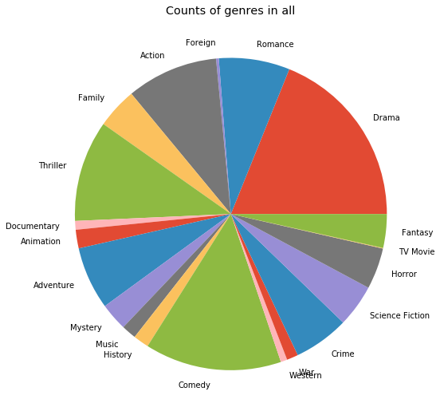

```python
# The totle counts of movies by genres
plt.figure(figsize=(9,9))
plt.pie(labels=genres.columns,x=genres.sum(axis=0))
plt.title('Counts of genres in all')
```

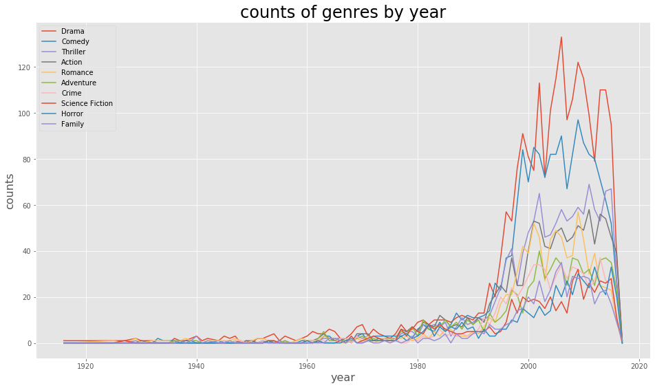

```python
# make a plot to see the year trend of the movies by genges (the first ten genges)
gen_c=list(genres.sum().sort_values(ascending=False).index[0:10])
plt.figure(figsize=(16,9))
plt.plot(gen_sum)
plt.title('counts of genres by year',fontsize=24)
plt.xlabel('year',fontsize=16)
plt.ylabel('counts',fontsize=16)
plt.legend(gen_sum.columns,loc='upper left')
```

### 3.1.2 profits(budgets) by genres

The cost of making a movie type varies, so the following is a study of the relationship between the type of film and the cost and benefits.

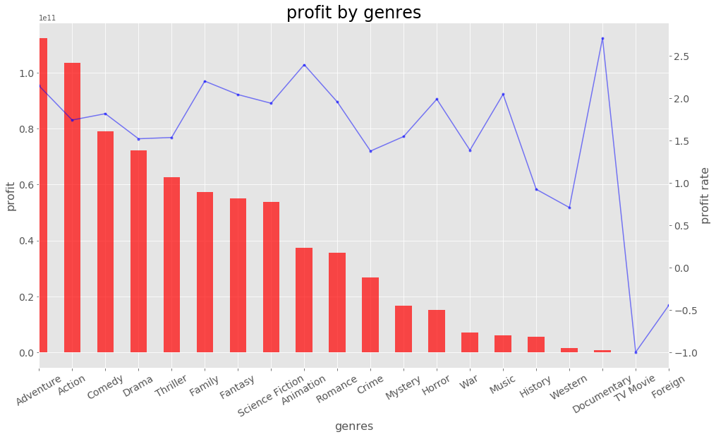

```python
columns_2=['budget','revenue']
genres_profit=pd.concat([genres,mydata[columns_2]],axis=1)
# Create a new data frame
genres2=pd.DataFrame()
for i in genres.columns:
    genres2[i]=genres_profit.groupby(i)[columns_2].sum().loc[1,:]
# Transpose data frame
genres2=genres2.T
genres2['profit']=genres2['revenue']-genres2['budget']
genres2['profitRate']=genres2['profit']/genres2['budget']
genres2=genres2.sort_values(by='profit',ascending=False)
# make a plot
f,ax1=plt.subplots(figsize=(16,9))
pro=genres2['profit']
pro.plot(kind='bar',ax=ax1,color='r',alpha=.7,fontsize=14,rot=30)
ax2=ax1.twinx()
prop=genres2['profitRate']
prop.plot(ax=ax2,alpha=.5,style='b.-',fontsize=14)
ax2.grid(False)
plt.title('profit by genres',fontsize=24)
ax1.set_ylabel('profit',fontsize=16)
ax1.set_xlabel('genres',fontsize=16)
ax2.set_ylabel('profit rate',fontsize=16)
```

From the plot, we can see adventure and action are ahead in the film genre, followed by comedy and drama , while other types of films are flat and far less profitable than the top four. In the case of yield profit rate, most are greater than 1.0, with the highest yield being documentary, which is 2.6 but less overall.

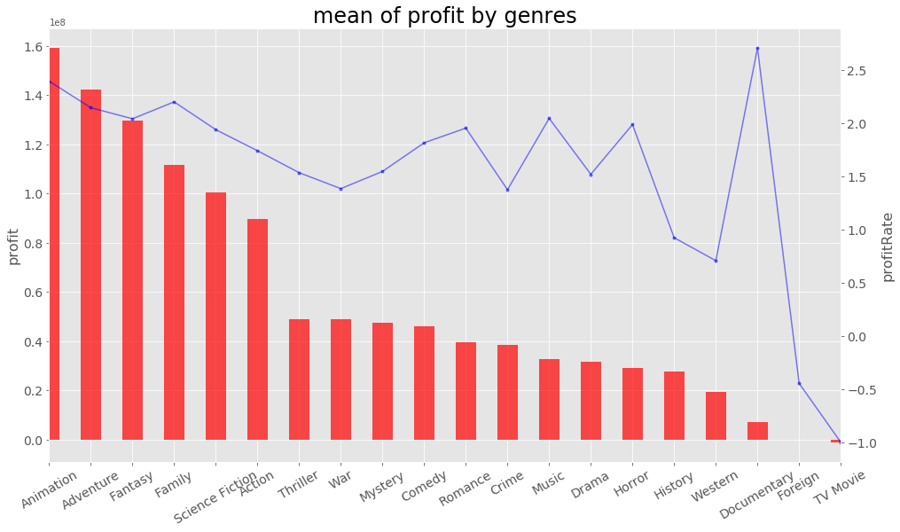

```python
genres_mean=pd.DataFrame()
for i in genres.columns:
    genres_mean[i]=genres_profit.groupby(i)[columns_2].mean().loc[1,:]
genres_mean=genres_mean.T
genres_mean['profit']=genres_mean['revenue']-genres_mean['budget']
genres_mean['profitRate']=genres_mean['profit']/genres_mean['budget']
genres_mean=genres_mean.sort_values(by='profit',ascending=False)
# Make a plot
f,ax1=plt.subplots(figsize=(16,9))
genres_mean['profit'].plot(kind='bar',ax=ax1,color='r',alpha=0.7,fontsize=14,rot=30)
ax2=ax1.twinx()
genres_mean['profitRate'].plot(ax=ax2,alpha=.5,style='b.-',fontsize=14)
ax2.grid(False)
plt.title('mean of profit by genres',fontsize=24)
ax1.set_ylabel('profit',fontsize=16)
ax2.set_ylabel('profitRate',fontsize=16)
```

Unlike the above sum of profits, the average profit return per style per movie. The top 5 are animation, adventur, fantasy, family and science fiction. In addition to animation, adventure and action movies that remain largely high-yielding, the other two films are in a low-yield state, but the yield is also more than 1.0, indicating that these are small-cost movies, small investment, returns a lot.

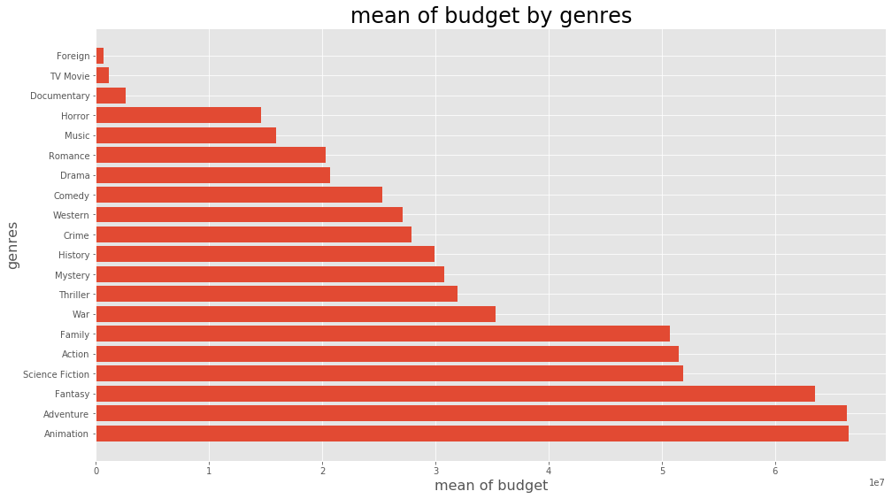

```python
genres_budget=pd.concat([genres,mydata['budget']],axis=1)
genres3=pd.Series()
for i in genres.columns:
    genres3[i]=genres_budget.groupby(i)['budget'].mean()[1]
genres3=genres3.sort_values(ascending=False)
# Make a plot
plt.figure(figsize=(16,9))
plt.barh(range(len(genres3)), genres3, tick_label=genres3.index)
plt.xlabel('mean of budget',fontsize='16')
plt.ylabel('genres',fontsize='16')
plt.title('mean of budget by genres',fontsize=24)
```

The top five of the budget are: animation, adventure, fantasy, science fiction and action, which has 4 same genres compared to the mean of profit. Except the top 6 genres, other types of films are flat and far less costable than the top six.

### 3.1.3 popularity by genres

The popularity of different movie types reflects people's different entertainment learning needs. So research can reflect people's desire and lack to some extent.

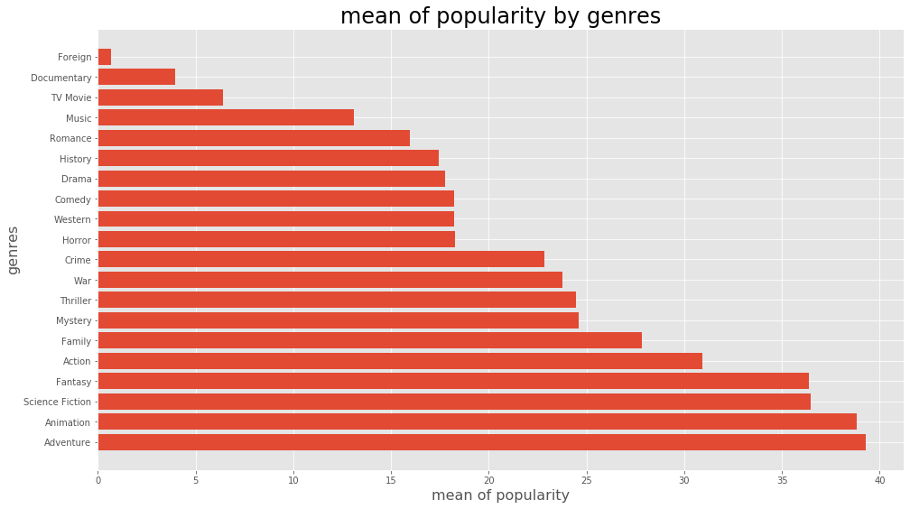

```python
genres_popu=pd.concat([genres,mydata['popularity']],axis=1)
genres4=pd.Series()
for i in genres.columns:
    genres4[i]=genres_popu.groupby(i)['popularity'].mean()[1]
genres4=genres4.sort_values(ascending=False)
# Make a plot
plt.figure(figsize=(16,9))
plt.barh(range(len(genres4)), genres4, tick_label=genres4.index)
plt.xlabel('mean of popularity',fontsize='16')
plt.ylabel('genres',fontsize='16')
plt.title('mean of popularity by genres',fontsize=24)
```

From the plot, animation, science Fiction, adventur and fantasy are the most popular, the other categories are lower than the previous level. It reflects people's curiosity about the unknown, their genuine love of children, and their desire for family emotions.

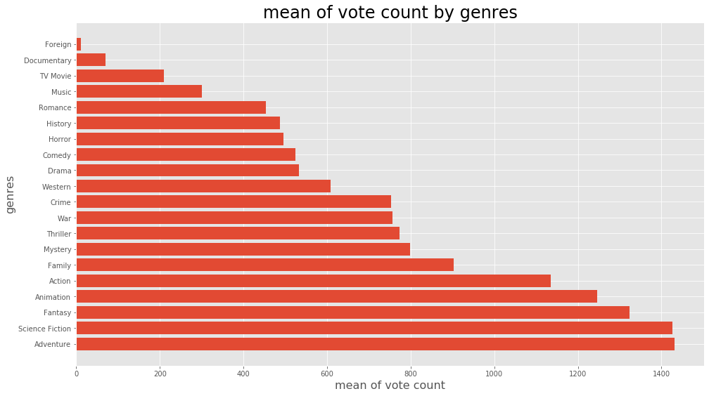

```python
genres_vote_count=pd.concat([genres,mydata['vote_count']],axis=1)
genres5=pd.Series()
for i in genres.columns:
    genres5[i]=genres_vote_count.groupby(i)['vote_count'].mean()[1]
genres5=genres5.sort_values(ascending=False)
# Make a plot
plt.figure(figsize=(16,9))
plt.barh(range(len(genres5)), genres5, tick_label=genres5.index)
plt.xlabel('mean of vote count',fontsize='16')
plt.ylabel('genres',fontsize='16')
plt.title('mean of vote count by genres',fontsize=24)
```

From the plot, the top five reviews are adventure, science fiction, fantasy, animation and action, which can also reflect the popular trends of various styles of films, And the above fiture of the mean of popularity by genres corresponding, the more times of evaluation, the higher the popularity!

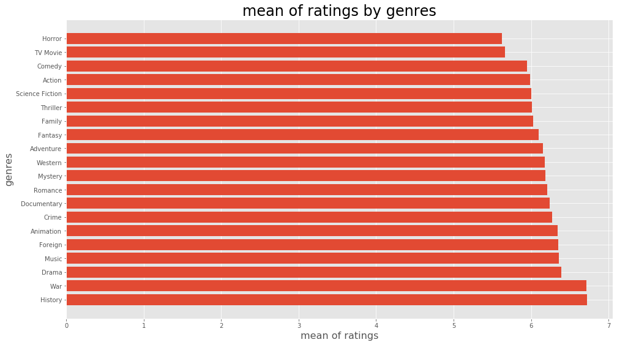

```python
genres_vote_avg=pd.concat([genres,mydata['vote_average']],axis=1)
genres6=pd.Series()
for i in genres.columns:
    genres6[i]=genres_vote_avg.groupby(i)['vote_average'].mean()[1]
genres6=genres6.sort_values(ascending=False)
# Make a plot
plt.figure(figsize=(16,9))
plt.barh(range(len(genres6)), genres6, tick_label=genres6.index)
plt.xlabel('mean of ratings',fontsize='16')
plt.ylabel('genres',fontsize='16')
plt.title('mean of ratings by genres',fontsize=24)
```

From the plot, the top five rated are history, war, drama, music and foreign. For the whole genres, the average score of each style is not very different, so-called radish cabbage, which means everyone has their own taste.

## 3.2 Top 20 Directors(based on the number of movies)

```python
## seperate the directors and sum the number of movies they directed.
drct=set()
for i in mydata['directors'].str.split('|'):
    drct=set().union(i,drct)
drct.remove('')
drct=list(drct)
```

```python
# Create a dataframe of director
directors=pd.DataFrame()
for i in drct:
    directors[i]=mydata['directors'].str.contains(i).apply(lambda x:1 if x else 0)
director=directors.sum().sort_values(ascending=False)
direct = {'director':director.index,'numbers':director.values}
director = pd.DataFrame(direct)
```

```python
# Merge the director to mydata
director=pd.merge(director,mydata,left_on='director',right_on='directors')
```

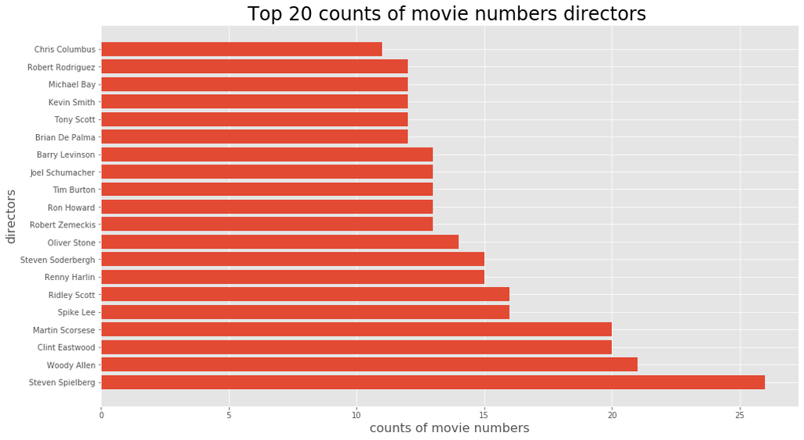

```python
direct=director['director'].value_counts()
direct1=direct[:20]
# Make a plot
plt.figure(figsize=(16,9))
plt.barh(range(len(direct1)), direct1, tick_label=direct1.index)
plt.xlabel('counts of movie numbers',fontsize='16')
plt.ylabel('directors',fontsize='16')
plt.title('Top 20 counts of movie numbers directors ',fontsize=24)
```

From the plot, we can see the top 20 directors in this database, based on the number of movies they had shotted. The first four directors who shot the most movies were Steven Spielberg, Woody Allen, Martin Scorsese, and Clint Eastwood, with the count number of 26, 21, 20, and 20. Even the 20th-ranked director has directed 11 films.

Then the mean revenue of these directors have been ploted below.

```python
direct=director['director'].value_counts().to_frame().reset_index().copy()
direct2=direct[:20]
direct2.rename(columns={'index':'directors','director':'number'},inplace=True)
direct3=director.groupby('director')['revenue'].mean().to_frame().reset_index()
direct4=pd.merge(direct2,direct3,how='left',left_on='directors',right_on='director')
```

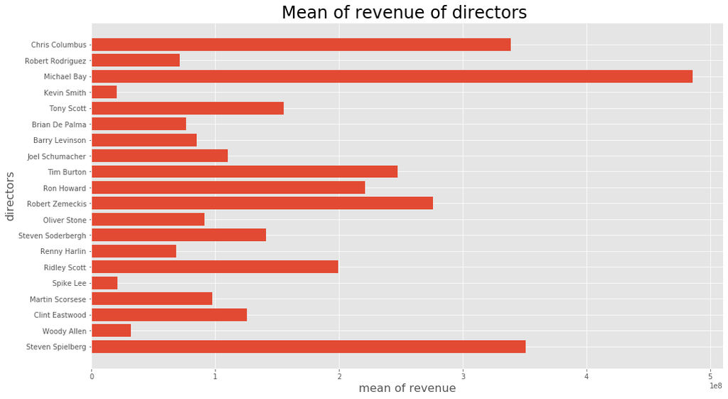

```python
plt.figure(figsize=(16,9))
plt.barh(range(len(direct4)), direct4['revenue'], tick_label=direct4['director'])
plt.xlabel('mean of revenue',fontsize='16')
plt.ylabel('directors',fontsize='16')
plt.title('Mean of revenue of directors ',fontsize=24)
```

This plot shows that the mean of the revenue of the top 20 directors varied a lot. From the plot, Michael Bay, Steven Spielberg and Chris Columbus has the most mean revenue among those directors. In response to this situation, I propose two possible reasons. First, it may be because different directors direct the film's types of differences, resulting in different income. In this respect, it is because of the genre of film, not the director's. The second possibility is that the director's different box-office appeal leads to different yields on the film. To see the causation of the difference in earnings, the average yield of different directors' films will be explored.

The plot shows below.

```python
# Create a dataframe to calculate the profits
direct5=director.groupby('director')['budget'].mean().to_frame().reset_index()
direct6=pd.merge(direct4,direct5,how='left',left_on='director',right_on='director')
direct6['profit']=direct6['revenue']/direct6['budget']
```

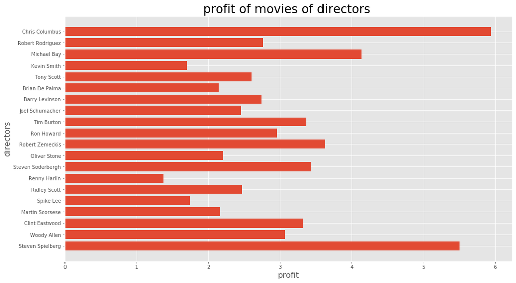

```python
plt.figure(figsize=(16,9))
plt.barh(range(len(direct6)), direct6['profit'], tick_label=direct6['director'])
plt.xlabel('profit',fontsize='16')
plt.ylabel('directors',fontsize='16')
plt.title('profit of movies of directors ',fontsize=24)
```

From the plot, we can figure out that Michael Bay, Steven Spielberg and Chris Columbus are still the top three, which confirms the previous guess ii that director's different box-office appeal leads to different yields on the film.

In addition to the director's box office appeal, film ratings are also an important basis for evaluating directors, so the figure below shows the average rating and the highest ratings for the 20 directors.

[figure not shown]

```python
# Make a rating plot by directors
direct7=director.groupby('director')['vote_average'].describe()
direct8=pd.merge(direct2,direct7,how='left',left_on='directors',right_on='director')
direct8.set_index(['directors'], inplace=True)
f,ax1=plt.subplots(figsize=(16,9))
direct8['mean'].plot(kind='bar',ax=ax1,color='r',alpha=0.7,fontsize=14,rot=30)
ax2=ax1.twinx()
direct8['max'].plot(ax=ax2,alpha=.5,style='b.-',fontsize=14)
ax2.grid(False)
plt.title('mean of profit by genres',fontsize=24)
ax1.set_ylabel('mean ratings',fontsize=16)
ax2.set_ylabel('max ratings',fontsize=16)
```

## 3.3 Correlation of main variables

When we look at movies, we wonder if the relationship between ratings, earnings, and popularity is relevant, in addition to caring about movie categories and cast members. Master component analysis is a multi-statistical method that examines the correlation between multiple variables and studies how to reveal the internal structure between multiple variables through a few main components, exports a few main components from the original variables so that they retain as much information as possible about the original variables and are not related to each other. So we're going to use the main component analysis below to look for the relationship between runtime, popularity, budget, revenue, rating and vote count.

The following image is a PCA diagram for the six variables.

```python
# Set the labels
labels = ['runtime', 'popularity','budget', 'revenue','vote_average','vote_count']
# Separating out the features
x = mydata[labels]
y = mydata['title_x']
# Scaled the variables
LE = LabelEncoder()
scaler = StandardScaler()
scaler.fit(x)
x_scaled=scaler.transform(x)
pca = PCA(n_components=2)
pca.fit(x_scaled)
```

```
PCA(copy=True, iterated_power='auto', n_components=2, random_state=None,
    svd_solver='auto', tol=0.0, whiten=False)
```

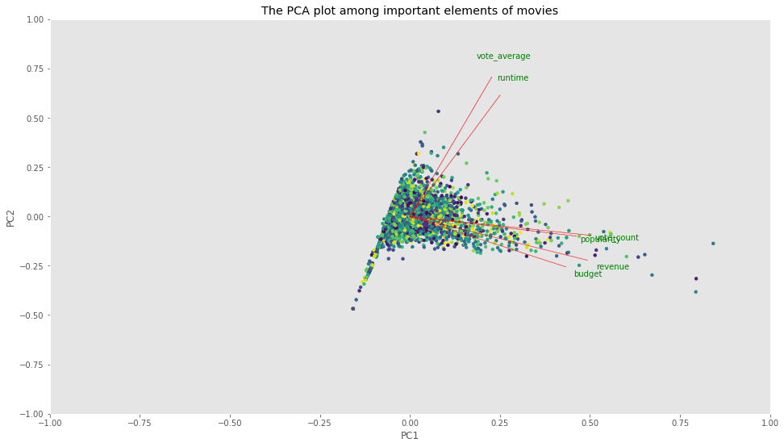

```python
# Code from https://stackoverﬂow.com/questions/39216897/ plot-pca-loadings-and-loading-in-biplot-in-sklearn-like-rs-autoplot
def myplot(score,coeff,labels=None):
    xs = score[:,0]
    ys = score[:,1]
    n = coeff.shape[0]
    scalex = 1.0/(xs.max() - xs.min())
    scaley = 1.0/(ys.max() - ys.min())
    plt.figure(figsize=(16,9))
    plt.scatter(xs * scalex,ys * scaley, c = LE.fit_transform(y),s=15)
    for i in range(n):
        plt.arrow(0, 0, coeff[i,0], coeff[i,1],color = 'r',alpha = 0.5)
        if labels is None:
            plt.text(coeff[i,0]* 1.15, coeff[i,1] * 1.15, features[i], color = 'g', ha = 'center', va = 'center')
        else:
            plt.text(coeff[i,0]* 1.15, coeff[i,1] * 1.15, labels[i], color = 'g', ha = 'center', va = 'center')
    plt.xlim(-1,1)
    plt.ylim(-1,1)
    plt.xlabel("PC{}".format(1))
    plt.ylabel("PC{}".format(2))
    plt.title("The PCA plot among important elements of movies")
    plt.grid()
myplot(pca_scores[:,0:2],np.transpose(pca.components_[0:2, :]))
```

From the plot, we can see that the ratings and runtime have high positive contribution to the second main component with kind of positive contribution to the second main component, while the other four variables have high positive contribution to the first main component with little negative contribution to the second main component. Also, the budgets are kind of proportional to revenue. Besides, the popularity and vote count have almost identical effect on the two main components, which means the more popular the film is, the more people watch it, and more people rate it. To get a more intuitive feel, the side-by-side diagram below shows how much the six variables contribute to the two generated unrelated variables.

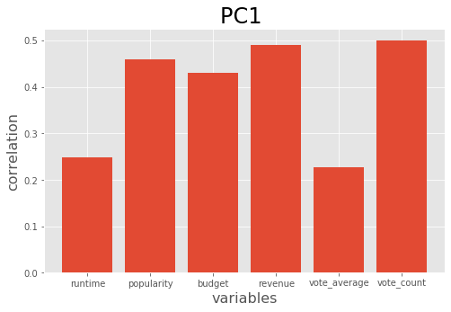

```python
pca_loadings = pca.components_
pca1=pd.DataFrame({'PC1':pca_loadings[0,:],'PC2':pca_loadings[1,:]})
plt.figure(figsize=(8,5))
plt.bar(range(len(pca1)), pca1['PC1'], tick_label=labels)
plt.xlabel('variables',fontsize='16')
plt.ylabel('correlation',fontsize='16')
plt.title('PC1 ',fontsize=24)
```

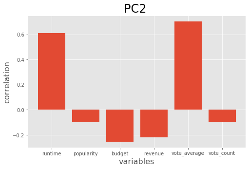

```python
plt.figure(figsize=(8,5))
plt.bar(range(len(pca1)), pca1['PC2'], tick_label=labels)
plt.xlabel('variables',fontsize='16')
plt.ylabel('correlation',fontsize='16')
plt.title('PC2 ',fontsize=24)
```

From these plots, we can see more clearly the quantitative contribution of each variable to the main component, which confirms the above analysis.

# Conclusion

# Appendix

### Original Data

```python
movie.head()
```

|  | budget | genres | homepage | id | keywords | original_language | original_title | overview | popularity | production_companies | production_countries | release_date | revenue | runtime | spoken_languages | status | tagline | title | vote_average | vote_count |
| --- | --- | --- | --- | --- | --- | --- | --- | --- | --- | --- | --- | --- | --- | --- | --- | --- | --- | --- | --- | --- |
| 0 | 237000000 | [{"id": 28, "name": "Action"}, {"id": 12, "nam... | http://www.avatarmovie.com/ | 19995 | [{"id": 1463, "name": "culture clash"}, {"id":... | en | Avatar | In the 22nd century, a paraplegic Marine is di... | 150.437577 | [{"name": "Ingenious Film Partners", "id": 289... | [{"iso_3166_1": "US", "name": "United States o... | 2009-12-10 | 2787965087 | 162.0 | [{"iso_639_1": "en", "name": "English"}, {"iso... | Released | Enter the World of Pandora. | Avatar | 7.2 | 11800 |
| 1 | 300000000 | [{"id": 12, "name": "Adventure"}, {"id": 14, "... | http://disney.go.com/disneypictures/pirates/ | 285 | [{"id": 270, "name": "ocean"}, {"id": 726, "na... | en | Pirates of the Caribbean: At World's End | Captain Barbossa, long believed to be dead, ha... | 139.082615 | [{"name": "Walt Disney Pictures", "id": 2}, {"... | [{"iso_3166_1": "US", "name": "United States o... | 2007-05-19 | 961000000 | 169.0 | [{"iso_639_1": "en", "name": "English"}] | Released | At the end of the world, the adventure begins. | Pirates of the Caribbean: At World's End | 6.9 | 4500 |
| 2 | 245000000 | [{"id": 28, "name": "Action"}, {"id": 12, "nam... | http://www.sonypictures.com/movies/spectre/ | 206647 | [{"id": 470, "name": "spy"}, {"id": 818, "name... | en | Spectre | A cryptic message from Bond’s past sends him o... | 107.376788 | [{"name": "Columbia Pictures", "id": 5}, {"nam... | [{"iso_3166_1": "GB", "name": "United Kingdom"... | 2015-10-26 | 880674609 | 148.0 | [{"iso_639_1": "fr", "name": "Fran\u00e7ais"},... | Released | A Plan No One Escapes | Spectre | 6.3 | 4466 |
| 3 | 250000000 | [{"id": 28, "name": "Action"}, {"id": 80, "nam... | http://www.thedarkknightrises.com/ | 49026 | [{"id": 849, "name": "dc comics"}, {"id": 853,... | en | The Dark Knight Rises | Following the death of District Attorney Harve... | 112.312950 | [{"name": "Legendary Pictures", "id": 923}, {"... | [{"iso_3166_1": "US", "name": "United States o... | 2012-07-16 | 1084939099 | 165.0 | [{"iso_639_1": "en", "name": "English"}] | Released | The Legend Ends | The Dark Knight Rises | 7.6 | 9106 |
| 4 | 260000000 | [{"id": 28, "name": "Action"}, {"id": 12, "nam... | http://movies.disney.com/john-carter | 49529 | [{"id": 818, "name": "based on novel"}, {"id":... | en | John Carter | John Carter is a war-weary, former military ca... | 43.926995 | [{"name": "Walt Disney Pictures", "id": 2}] | [{"iso_3166_1": "US", "name": "United States o... | 2012-03-07 | 284139100 | 132.0 | [{"iso_639_1": "en", "name": "English"}] | Released | Lost in our world, found in another. | John Carter | 6.1 | 2124 |

```python
movie.shape
```

```
(4803, 20)
```

```python
credit.head()
```

|  | movie_id | title | cast | crew |
| --- | --- | --- | --- | --- |
| 0 | 19995 | Avatar | [{"cast_id": 242, "character": "Jake Sully", "... | [{"credit_id": "52fe48009251416c750aca23", "de... |
| 1 | 285 | Pirates of the Caribbean: At World's End | [{"cast_id": 4, "character": "Captain Jack Spa... | [{"credit_id": "52fe4232c3a36847f800b579", "de... |
| 2 | 206647 | Spectre | [{"cast_id": 1, "character": "James Bond", "cr... | [{"credit_id": "54805967c3a36829b5002c41", "de... |
| 3 | 49026 | The Dark Knight Rises | [{"cast_id": 2, "character": "Bruce Wayne / Ba... | [{"credit_id": "52fe4781c3a36847f81398c3", "de... |
| 4 | 49529 | John Carter | [{"cast_id": 5, "character": "John Carter", "c... | [{"credit_id": "52fe479ac3a36847f813eaa3", "de... |

```python
credit.shape
```

```
(4803, 4)
```

### Processed Data

```python
## View the processed dataframe
mydata.head()
```

|  | budget | genres | id | keywords | original_language | popularity | production_companies | production_countries | release_date | revenue | runtime | title_x | vote_average | vote_count | actors | directors | year |
| --- | --- | --- | --- | --- | --- | --- | --- | --- | --- | --- | --- | --- | --- | --- | --- | --- | --- |
| 0 | 237000000 | Action\|Adventure\|Fantasy\|Science Fiction | 19995 | culture clash\|future\|space war\|space colony\|so... | en | 150.437577 | Ingenious Film Partners\|Twentieth Century Fox ... | United States of America\|United Kingdom | 2009-12-10 | 2787965087 | 162.0 | Avatar | 7.2 | 11800 | Sam Worthington\|Zoe Saldana\|Sigourney Weaver\|S... | James Cameron | 2009 |
| 1 | 300000000 | Adventure\|Fantasy\|Action | 285 | ocean\|drug abuse\|exotic island\|east india trad... | en | 139.082615 | Walt Disney Pictures\|Jerry Bruckheimer Films\|S... | United States of America | 2007-05-19 | 961000000 | 169.0 | Pirates of the Caribbean: At World's End | 6.9 | 4500 | Johnny Depp\|Orlando Bloom\|Keira Knightley\|Stel... | Gore Verbinski | 2007 |
| 2 | 245000000 | Action\|Adventure\|Crime | 206647 | spy\|based on novel\|secret agent\|sequel\|mi6\|bri... | en | 107.376788 | Columbia Pictures\|Danjaq\|B24 | United Kingdom\|United States of America | 2015-10-26 | 880674609 | 148.0 | Spectre | 6.3 | 4466 | Daniel Craig\|Christoph Waltz\|Léa Seydoux\|Ralph... | Sam Mendes | 2015 |
| 3 | 250000000 | Action\|Crime\|Drama\|Thriller | 49026 | dc comics\|crime fighter\|terrorist\|secret ident... | en | 112.312950 | Legendary Pictures\|Warner Bros.\|DC Entertainme... | United States of America | 2012-07-16 | 1084939099 | 165.0 | The Dark Knight Rises | 7.6 | 9106 | Christian Bale\|Michael Caine\|Gary Oldman\|Anne ... | Christopher Nolan | 2012 |
| 4 | 260000000 | Action\|Adventure\|Science Fiction | 49529 | based on novel\|mars\|medallion\|space travel\|pri... | en | 43.926995 | Walt Disney Pictures | United States of America | 2012-03-07 | 284139100 | 132.0 | John Carter | 6.1 | 2124 | Taylor Kitsch\|Lynn Collins\|Samantha Morton\|Wil... | Andrew Stanton | 2012 |

```python
mydata.shape
```

```
(4803, 17)
```

```python
# Explore the data
mydata.describe()
```

|  | budget | id | popularity | revenue | runtime | vote_average | vote_count | year |
| --- | --- | --- | --- | --- | --- | --- | --- | --- |
| count | 4.803000e+03 | 4803.000000 | 4803.000000 | 4.803000e+03 | 4803.000000 | 4803.000000 | 4803.000000 | 4803.000000 |
| mean | 2.904504e+07 | 57165.484281 | 21.492301 | 8.226064e+07 | 106.868624 | 6.092172 | 690.217989 | 2002.471788 |
| std | 4.072239e+07 | 88694.614033 | 31.816650 | 1.628571e+08 | 22.610670 | 1.194612 | 1234.585891 | 12.414832 |
| min | 0.000000e+00 | 5.000000 | 0.000000 | 0.000000e+00 | 0.000000 | 0.000000 | 0.000000 | 1916.000000 |
| 25% | 7.900000e+05 | 9014.500000 | 4.668070 | 0.000000e+00 | 94.000000 | 5.600000 | 54.000000 | 1999.000000 |
| 50% | 1.500000e+07 | 14629.000000 | 12.921594 | 1.917000e+07 | 103.000000 | 6.200000 | 235.000000 | 2005.000000 |
| 75% | 4.000000e+07 | 58610.500000 | 28.313505 | 9.291719e+07 | 117.500000 | 6.800000 | 737.000000 | 2011.000000 |
| max | 3.800000e+08 | 459488.000000 | 875.581305 | 2.787965e+09 | 338.000000 | 10.000000 | 13752.000000 | 2017.000000 |

### Scatterplot of the relationship between variables

Explore the relationship between variables to see if there is a correlation among variables. From this part, the pca is decided to be part of the questions

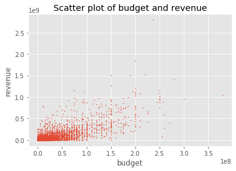

```python
## Make the scatter plot to see the relationship between variables
plt.scatter(mydata['budget'],mydata['revenue'],s=1)
plt.title('Scatter plot of budget and revenue')
plt.xlabel('budget')
plt.ylabel('revenue')
```

[figure not shown]

```python
plt.scatter(mydata['vote_average'],mydata['budget'],s=1)
plt.title('Scatter plot of budget and ratings')
plt.xlabel('budget')
plt.ylabel('ratings')
```

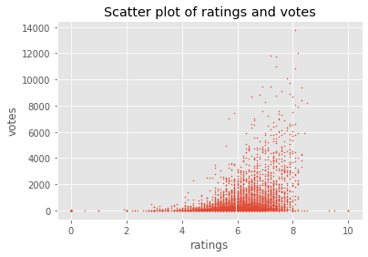

```python
plt.scatter(mydata['vote_average'],mydata['vote_count'],s=1)
plt.title('Scatter plot of ratings and votes')
plt.xlabel('ratings')
plt.ylabel('votes')
```

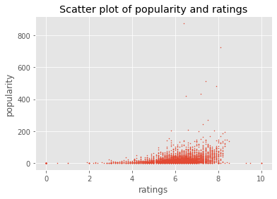

```python
plt.scatter(mydata['vote_average'],mydata['popularity'],s=1)
plt.title('Scatter plot of popularity and ratings')
plt.xlabel('ratings')
plt.ylabel('popularity')
```

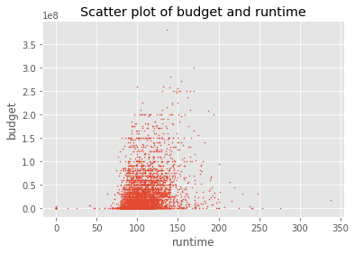

```python
plt.scatter(mydata['runtime'],mydata['budget'],s=1)
plt.title('Scatter plot of budget and runtime')
plt.xlabel('runtime')
plt.ylabel('budget')
```

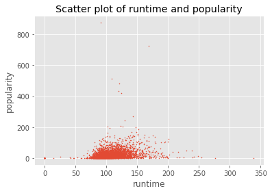

```python
plt.scatter(mydata['runtime'],mydata['popularity'],s=1)
plt.title('Scatter plot of runtime and popularity')
plt.xlabel('runtime')
plt.ylabel('popularity')
```